# Test a Perceptual Phenomenon

### Analyzing the Stroop Effect

Perform the analysis in the space below. Remember to follow [the instructions](https://docs.google.com/document/d/1-OkpZLjG_kX9J6LIQ5IltsqMzVWjh36QpnP2RYpVdPU/pub?embedded=True) and review the [project rubric](https://review.udacity.com/#!/rubrics/71/view) before submitting. Once you've completed the analysis and write up, download this file as a PDF or HTML file and submit in the next section.

(1) What is the independent variable? What is the dependent variable?

###### Congruent word / Incongruent word is the independent variable

###### Time taken to read the congreunt/Incogruent word is the Dependent variable.

(2) What is an appropriate set of hypotheses for this task? What kind of statistical test do you expect to perform? Justify your choices.

###### Null Hypothesis : **$H_{0}$**

###### For the overall population, Average Time taken to read the congruent word (**$\mu_{C}$**) is equal to Average time taken to read the Incongruent Word (**$\mu_{I}$**)

**$H_{0}: \mu_{C}$** = **$\mu_{I}$**

###### Alternate Hypothesis : **$H_{1}$**

###### For the overall population, Average Time taken to read the congruent word (**$\mu_{C}$**) is Not equal to Average time taken to read the Incongruent Word (**$\mu_{I}$**)

**$H_{1}: \mu_{C}$** ≠ **$\mu_{I}$**

##### To infer the population mean based on the given sample data - we can use 'Z' Test or 'T' Test. Since we have sample size less than 30, then it and also we do not have the population standard deviation (which will make 'Z' test effective) - so 'T' Test will be more meaningful for our scenario. we will be using Paired 'T' Test since our given sample data has pair of observations (one for congruent and another for incongruent). It will be two tailed test since as per our alternate hypothesis we have the condition population average time for congruent word is not equal to population average time for Incongruent word .

##### we have assumptions as listed below

#### The observations are independent of one another.

#### The dependent variable should not contain any outliers.

#### The dependent variable should be approximately normally distributed.

(3) Report some descriptive statistics regarding this dataset. Include at least one measure of central tendency and at least one measure of variability. The name of the data file is 'stroopdata.csv'.

```python
# Perform the analysis here
# Import packages
import pandas as pd
import scipy.stats as stats
import numpy as np
import matplotlib.pyplot as plt
%matplotlib inline

# Code to read the CSV file
df_stroop = pd.read_csv('stroopdata.csv')
df_stroop.head()

# Measure the mean of Data
print(np.mean(df_stroop['Congruent']))
print(np.mean(df_stroop['Incongruent']))

# Measure the median of Data
print(np.median(df_stroop['Congruent']))
print(np.median(df_stroop['Incongruent']))

### Measure the variance of the data
print(np.var(df_stroop['Congruent'],ddof=1))
print(np.var(df_stroop['Incongruent'],ddof=1))


### Measure the Standard Deviation of the data
print(np.std(df_stroop['Congruent'],ddof=1))
print(np.std(df_stroop['Incongruent'],ddof=1))
```

```
14.051125
22.0159166667
14.3565
21.0175
12.6690290707
23.0117570362
3.55935795765
4.79705712247
```

### Congruent Data - Mean Time taken - 14.05 seconds

### Incongruent Data - Mean Time taken - 22.01 seconds

### Congruent Data - Median Time taken - 14.35 seconds

### InCongruent Data - Median Time taken - 21.01 seconds

### Congruent Data - Variance is 12.66 and Standard deviation is 3.55

### Incongruent Data - variance is 23.01 and Standard deviation is 4.79

(4) Provide one or two visualizations that show the distribution of the sample data. Write one or two sentences noting what you observe about the plot or plots.

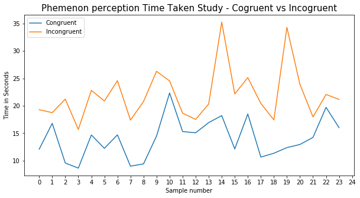

```python
# Build the visualizations here
plt.figure(figsize=(10,5))
plt.xticks(range(0,30))
plt.plot(df_stroop['Congruent'])
plt.plot(df_stroop['Incongruent'])
plt.title('Phemenon perception Time Taken Study - Cogruent vs Incogruent',fontsize=15)
plt.xlabel('Sample number')
plt.ylabel('Time in Seconds')
plt.legend(loc='upper left')
```

### Based on the above line plot, it is evident that Incogruent time data always has higher value than the congruent data

(5) Now, perform the statistical test and report the results. What is the confidence level and your critical statistic value? Do you reject the null hypothesis or fail to reject it? Come to a conclusion in terms of the experiment task. Did the results match up with your expectations?

```python
# Perform the statistical test here
stats.ttest_rel(df_stroop['Congruent'],df_stroop['Incongruent'])
```

```
Ttest_relResult(statistic=-8.020706944109957, pvalue=4.1030005857111781e-08)
```

###### Based on the very low p value - we can infer it is statistically significant and hence we can reject the null hypothesis.

###### Alternate hypothesis is true.

###### Average time to read a incongruent word is not equal to Average time to read a congruent word. We can see that Average time to read a incongruent word is greater than the Average time to read a congruent word.